# The BATTLE Trial: A Case Study on Biomarker-Guided, Bayesian Adaptive Trial

## 7.2 Overall efficacy, and the primary endpoint

Among the **244** patients evaluable at 8 weeks, the overall DCR@8w was **46%** (112/244), with **no complete responses and only 9 partial responses** — typical cytostatic activity for targeted agents in this setting. Median PFS was **1.9 months** (95% CI 1.8–2.4), median OS **8.8 months** (95% CI 6.4–10.6), and 1-year survival **35%**. In a pre-specified-style landmark analysis anchored at week 8, patients with disease control lived longer (median 9.6 months, 95% CI 7.4–12.5) than those without (7.5 months, 95% CI 4.2–9.2; P = 0.018) (Kim et al. 2011). Treatment-related grade 3–4 toxicity was **6.5%** and compliance exceeded 95% in every arm; sorafenib caused the most toxicity (treatment discontinuation in 19%, dose reductions in 21%) (Kim et al. 2011).

To visualize the marginal results with honest uncertainty, we recompute **Wilson score intervals** (Equation 9) from the documented counts and plot them in Figure 8 — a reconstruction of published summaries, not new inference on patient-level data:

$$\tilde p = \frac{\hat p + z^2/(2n)}{1 + z^2/n}, \qquad
\text{CI}_{1-\alpha}(\gamma) =
\tilde p \pm \frac{z}{1 + z^2/n}\,
\sqrt{\frac{\hat p (1 - \hat p)}{n} + \frac{z^2}{4 n^2}}
\tag{9}$$

In Equation 9, $\hat p = x/n$ is the observed DCR in a cell with $x$ disease-control successes among $n$ evaluable patients and $z = 1.96$ for a 95% interval; $\tilde p$ is the interval’s center, pulled slightly toward 1/2 relative to $\hat p$. The Wilson interval behaves well for the small cell counts ($n$ as low as 3) that adaptive trials inevitably produce — unlike the Wald interval, it never leaves $[0,1]$ and stays sane near the boundaries.

**Show the R code**

[figure not shown]

Figure 8: Documented 8-week disease control by arm, with 95% Wilson intervals (Equation 9) computed from the published counts — erlotinib 20/58, vandetanib 17/52, erlotinib + bexarotene 18/36, sorafenib 57/98 (Kim et al. 2011); the sorafenib interval brackets the 58.2% reported by the arm’s final paper (Blumenschein et al. 2013). Dashed line: 30% historical DCR benchmark used in the success rule (Kim et al. 2011; Lara, Redman, and Kelly 2008). This is a marginal, all-comers view — the design’s inference lives at the arm × marker-group level (Fig. Figure 9).

```r
wilson <- function(x, n, z = 1.959964) {
  p <- x / n
  d <- 1 + z^2 / n
  ctr <- (p + z^2 / (2 * n)) / d
  hw  <- (z / d) * sqrt(p * (1 - p) / n + z^2 / (4 * n^2))
  c(ctr - hw, ctr + hw)
}
arms_df <- data.frame(
  arm = c("Erlotinib", "Vandetanib", "Erlotinib +\nbexarotene", "Sorafenib"),
  x = c(20, 17, 18, 57),
  n = c(58, 52, 36, 98))
ci_ar <- t(sapply(seq_len(nrow(arms_df)), function(i) wilson(arms_df$x[i], arms_df$n[i])))
arms_df$pct <- 100 * arms_df$x / arms_df$n
arms_df$lo  <- 100 * ci_ar[, 1]
arms_df$hi  <- 100 * ci_ar[, 2]
ggplot(arms_df, aes(arm, pct, fill = arm)) +
  geom_col(alpha = 0.85, width = 0.62, colour = "grey25", linewidth = 0.25) +
  geom_errorbar(aes(ymin = lo, ymax = hi), width = 0.09, linewidth = 0.55) +
  geom_hline(yintercept = 30, linetype = 2, colour = "grey40") +
  geom_text(aes(label = paste0(x, "/", n, "  (", round(pct), "%)")),
            vjust = -1.0, size = 3.0) +
  scale_fill_manual(values = pal[1:4]) +
  scale_y_continuous(limits = c(0, 85), labels = percent) +
  labs(x = NULL, y = "8-week disease control rate",
       title = "Marginal DCR@8w by arm (documented counts, Wilson 95% CIs)") +
  annotate("text", x = 0.62, y = 31.5, size = 2.9, colour = "grey35",
           hjust = 0, label = "historical 30% DCR benchmark")
```

## 7.3 The heart of BATTLE: the arm × marker-group matrix

**Show the R code**

```r
dcr_cells <- tribble(
  ~group, ~erlotinib, ~vandetanib, ~elo_bex, ~sorafenib,
  "EGFR",           "6/17 (35%)",  "11/27 (41%)*", "11/20 (55%)*", "9/23 (39%)",
  "KRAS/BRAF",      "1/7 (14%)",   "0/3 (0%)",     "1/3 (33%)",    "11/14 (79%)*",
  "VEGF/VEGFR-2",   "10/25 (40%)*","6/16 (38%)",   "0/3 (0%)",     "25/39 (64%)*",
  "RXR/cyclin D1",  "0/1 (0%)",    "—",            "1/1 (100%)*",  "1/4 (25%)",
  "None/unknown",   "3/8 (38%)",   "0/6 (0%)",     "5/9 (56%)*",   "11/18 (61%)*",
  "Total",          "20/58 (34%)", "17/52 (33%)",  "18/36 (50%)",  "57/98 (58%)"
)
colnames(dcr_cells) <- c("Marker group", "Erlotinib", "Vandetanib",
                         "Erlotinib + bexarotene", "Sorafenib")
knitr::kable(dcr_cells, align = "lrrrr")
```

Table 4: Documented 8-week disease control by treatment and marker group (Table 2 of Kim et al. (2011)). Cells marked * were declared ‘effective’ per the design’s success rule, Pr(DCR > 30% | data) ≥ 0.80. Note the emptiness of the RXR/cyclin D1 row (only six patients) — the sparse cell that delayed adaptive randomization and later motivated the no-grouping redesign of BATTLE-2 (Liu and Lee 2015).

| Marker group | Erlotinib | Vandetanib | Erlotinib + bexarotene | Sorafenib |
| --- | --- | --- | --- | --- |
| EGFR | 6/17 (35%) | 11/27 (41%)* | 11/20 (55%)* | 9/23 (39%) |
| KRAS/BRAF | 1/7 (14%) | 0/3 (0%) | 1/3 (33%) | 11/14 (79%)* |
| VEGF/VEGFR-2 | 10/25 (40%)* | 6/16 (38%) | 0/3 (0%) | 25/39 (64%)* |
| RXR/cyclin D1 | 0/1 (0%) | — | 1/1 (100%)* | 1/4 (25%) |
| None/unknown | 3/8 (38%) | 0/6 (0%) | 5/9 (56%)* | 11/18 (61%)* |
| Total | 20/58 (34%) | 17/52 (33%) | 18/36 (50%) | 57/98 (58%) |

Read Table 4 — visualized as a heatmap in Figure 9 — the way the design intended: *down columns* are conventional marginal results; *across rows* is the trial’s real hypothesis test — within a marker group, which targeted agent controls disease? Sorafenib’s 79% (11/14) in *KRAS/BRAF*-mutant tumors against 14% for erlotinib and 0% for vandetanib is the pattern a biomarker-guided trial exists to find, and it confirmed the prespecified hypothesis for sorafenib in that class (Kim et al. 2011).

**Show the R code**

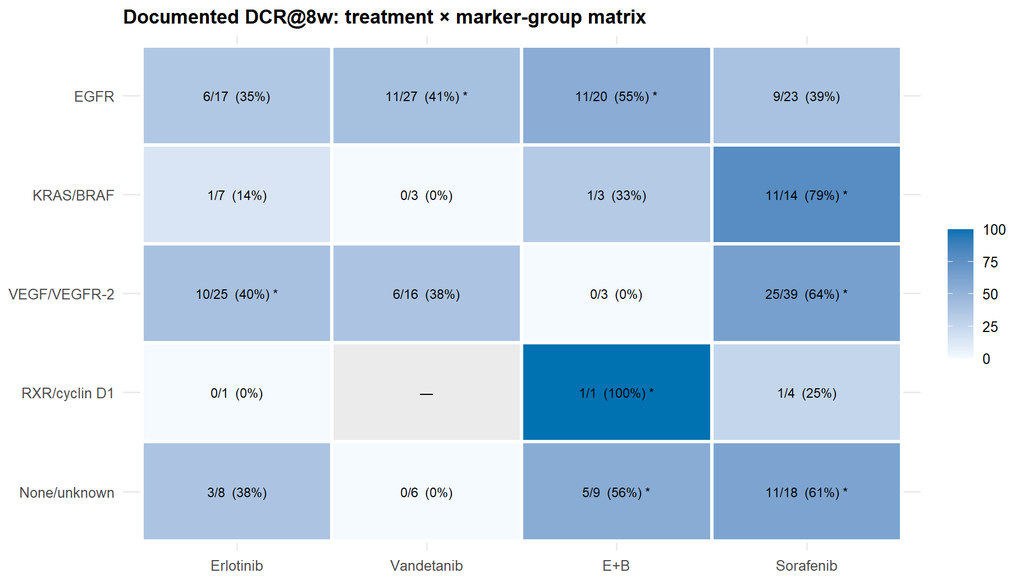

Figure 9: The same documented matrix as a heatmap (percentages; ‘—’ marks a cell with no patients). Asterisks denote the design’s ‘effective’ declarations — posterior probability of exceeding the 30% benchmark of at least 0.80 (Kim et al. 2011). Effective pairings: erlotinib in VEGF/VEGFR-2; vandetanib in EGFR; erlotinib + bexarotene in EGFR, RXR/cyclin D1 and none/unknown; sorafenib in KRAS/BRAF, VEGF/VEGFR-2 and none/unknown. The RXR/cyclin D1 row shows what tiny cell sizes do to a posterior — one success out of one patient yields a strikingly high posterior mean under a vague prior, a useful teaching point about hierarchical models with vague hyperpriors.

```r
hm <- tribble(
  ~group, ~arm, ~x, ~n, ~eff,
  "EGFR",          "Erlotinib",  6, 17, FALSE,
  "EGFR",          "Vandetanib", 11, 27, TRUE,
  "EGFR",          "E+B",        11, 20, TRUE,
  "EGFR",          "Sorafenib",  9, 23, FALSE,
  "KRAS/BRAF",     "Erlotinib",  1, 7, FALSE,
  "KRAS/BRAF",     "Vandetanib", 0, 3, FALSE,
  "KRAS/BRAF",     "E+B",        1, 3, FALSE,
  "KRAS/BRAF",     "Sorafenib",  11, 14, TRUE,
  "VEGF/VEGFR-2",  "Erlotinib",  10, 25, TRUE,
  "VEGF/VEGFR-2",  "Vandetanib", 6, 16, FALSE,
  "VEGF/VEGFR-2",  "E+B",        0, 3, FALSE,
  "VEGF/VEGFR-2",  "Sorafenib",  25, 39, TRUE,
  "RXR/cyclin D1", "Erlotinib",  0, 1, FALSE,
  "RXR/cyclin D1", "Vandetanib", 0, 0, FALSE,
  "RXR/cyclin D1", "E+B",        1, 1, TRUE,
  "RXR/cyclin D1", "Sorafenib",  1, 4, FALSE,
  "None/unknown",  "Erlotinib",  3, 8, FALSE,
  "None/unknown",  "Vandetanib", 0, 6, FALSE,
  "None/unknown",  "E+B",        5, 9, TRUE,
  "None/unknown",  "Sorafenib",  11, 18, TRUE)
hm$pct <- ifelse(hm$n == 0, NA_real_, 100 * hm$x / hm$n)
hm$lab <- ifelse(hm$n == 0, "—",
                 paste0(hm$x, "/", hm$n, "  (", round(hm$pct), "%)",
                        ifelse(hm$eff, " *", "")))
ggplot(hm, aes(factor(arm, levels = c("Erlotinib", "Vandetanib", "E+B", "Sorafenib")),
               factor(group, levels = rev(c("EGFR", "KRAS/BRAF",
        "VEGF/VEGFR-2", "RXR/cyclin D1", "None/unknown"))), fill = pct)) +
  geom_tile(colour = "white", linewidth = 1.1) +
  geom_text(aes(label = lab), size = 3.05, colour = "black") +
  scale_fill_gradient(low = "#F4FAFF", high = pal[1], na.value = "grey92") +
  labs(x = NULL, y = NULL, fill = "DCR@8w",
       title = "Documented DCR@8w: treatment × marker-group matrix") +
  theme(legend.position = "right")
```

## 7.4 Did adaptation actually happen? Yes — visibly

**Show the R code**

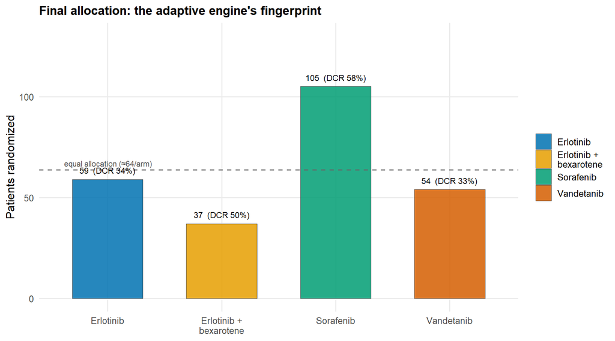

```r
al <- data.frame(
  arm = c("Erlotinib", "Vandetanib", "Erlotinib +\nbexarotene", "Sorafenib"),
  n_rand = c(59, 54, 37, 105),
  dcr = c(34, 33, 50, 58))
ggplot(al, aes(arm, n_rand, fill = arm)) +
  geom_col(alpha = 0.85, width = 0.62, colour = "grey25", linewidth = 0.25) +
  geom_hline(yintercept = 255 / 4, linetype = 2, colour = "grey40") +
  geom_text(aes(label = paste0(n_rand, "  (DCR ", dcr, "%)")),
            vjust = -0.9, size = 3.0) +
  scale_fill_manual(values = pal[1:4]) +
  scale_y_continuous(limits = c(0, 130)) +
  labs(x = NULL, y = "Patients randomized",
       title = "Final allocation: the adaptive engine's fingerprint") +
  annotate("text", x = 0.62, y = 67, size = 2.9, colour = "grey35", hjust = 0,
           label = "equal allocation (≈64/arm)")
```

## 7.5 The individual-marker story the grouping obscured

The team’s prespecified and exploratory single-marker analyses — run *after* the marker-group model had done its allocation work — sharpen the picture (Kim et al. 2011; Liu and Lee 2015):

- *EGFR* mutation predicted better 8-week control on **erlotinib** (P = 0.04): 71% DCR in *EGFR*-mutant versus 29% in wild-type tumors (Liu and Lee 2015).
- High **VEGFR-2** expression predicted benefit from **vandetanib** (P = 0.05), consistent with the arm’s mechanism (Kim et al. 2011).
- High **cyclin D1** expression (P = 0.01) and *EGFR* amplification (P = 0.006) predicted benefit from **erlotinib + bexarotene** — the RXR/cyclin D1 hypothesis finally visible only at the individual-marker level (Kim et al. 2011).
- For **sorafenib**, DCR was 64% in *EGFR*-wild-type tumors versus 33% for all other treatments combined (P < 0.001), with a trend in *KRAS*-mutant tumors (61% vs 32%, P = 0.11) (Kim et al. 2011); *EGFR* mutation (P = 0.01) and high polysomy (P = 0.05) predicted *worse* control on sorafenib (Kim et al. 2011).

Figure 11 draws these contrasts side by side.

**Show the R code**

[figure not shown]

Figure 11: Documented single-marker contrasts of 8-week DCR (percentages as published; p-values from the primary paper). Each row compares a treatment’s performance across marker-defined strata of the same patients. Sources: 71% vs 29% and 61% vs 22% from Liu and Lee (2015); 64% vs 33% (P < 0.001) and 61% vs 32% (P = 0.11) from Kim et al. (2011). The top row is why the trialists later regretted bundling EGFR mutation with copy-number markers: the grouped analysis understated the strongest signal in the trial.

```r
mk <- data.frame(
  contrast = c("EGFR-mutant vs EGFR-wild-type\n(on erlotinib)",
               "KRAS-mutant: sorafenib vs erlotinib",
               "EGFR-wild-type: sorafenib vs\nall other arms",
               "KRAS-mutant: sorafenib vs\nall other arms"),
  lo = c(29, 22, 33, 32),
  hi = c(71, 61, 64, 61),
  p  = c("P = 0.04", "P not reported", "P < 0.001", "P = 0.11"))
mk$contrast <- factor(mk$contrast, levels = rev(mk$contrast))
ggplot(mk, aes(x = lo, xend = hi, y = contrast, yend = contrast)) +
  geom_vline(xintercept = 30, linetype = 2, colour = "grey55") +
  geom_segment(linewidth = 1.6, colour = "grey55",
               arrow = arrow(length = unit(0.14, "cm"), type = "closed")) +
  geom_point(aes(x = lo), size = 3.4, colour = pal[2]) +
  geom_point(aes(x = hi), size = 3.4, colour = pal[1]) +
  geom_text(aes(x = (lo + hi) / 2, y = contrast, label = p),
            vjust = -1.05, size = 2.85, colour = "grey25") +
  scale_x_continuous(labels = percent, limits = c(15, 80)) +
  labs(x = "8-week disease control rate", y = NULL,
       title = "Single-marker contrasts (orange = comparator, blue = experimental)")
```

## 7.6 Arm postscripts published after the main paper

Three of the four arms received dedicated final publications that deepen the results in instructive ways. The **sorafenib** analysis confirmed the marginal DCR of 58.2% (98 evaluable), median PFS 2.83 months (95% CI 2.04–3.58) and OS 8.48 months (95% CI 5.78–10.97); DCR was higher in *EGFR*-wild-type than *EGFR*-mutant tumors (P = 0.012), and a gene-expression “sorafenib sensitivity signature” built from cell lines and BATTLE biopsies separated PFS (3.61 vs 1.84 months, P = 0.026) (Blumenschein et al. 2013). The **vandetanib** report showed overall activity (DCR 33%, median PFS 1.81 months, median OS 6.5 months) with an exploratory hint of benefit from dual VEGFR/EGFR blockade in *EGFR*-mutant, TKI-resistant tumors but no overall survival advantage (A. S. Tsao et al. 2013). An **elderly-subgroup** analysis found signals such as better PFS with vandetanib in men aged 65–70 and with sorafenib in men over 70 (A. S. Tsao, Liu, and Lee 2012). Banked specimens additionally yielded the KRAS-variant biology analysis (Ihle, Byers, and Kim 2012) and the 76-gene EMT resistance signature (Byers, Diao, and Wang 2013).

**Show the R code**

[figure not shown]

```r
tt <- seq(0, 24, by = 0.05)
surv_df <- data.frame(
  t = rep(tt, 2),
  S = c(0.5^(tt / 1.9), 0.5^(tt / 8.8)),
  curve = rep(c("PFS (median 1.9 months)", "OS (median 8.8 months)"),
              each = length(tt)))
ggplot(surv_df, aes(t, 100 * S, colour = curve)) +
  geom_line(linewidth = 0.9) +
  geom_vline(xintercept = 8, linetype = 2, colour = "grey45") +
  geom_hline(yintercept = 50, linetype = 3, colour = "grey60") +
  scale_colour_manual(values = c(pal[1], pal[4])) +
  scale_y_continuous(labels = percent) +
  labs(x = "Months since randomization", y = "Event-free proportion",
       title = "Illustrative exponential reconstruction of the published medians") +
  annotate("text", x = 8, y = 93, size = 2.9, colour = "grey35",
           label = "week 8: the primary endpoint's clock")
```

$$S(t) = 0.5^{\,t / m}
\tag{10}$$

In Equation 10, $S(t)$ is the event-free proportion at time $t$ and $m$ the median event time in months; the exponential is the unique survival model in which the hazard is constant, and it is used here purely as a visual calibration device, not as an inferential claim.

# 8 Regulatory interactions, guidance, and the path to acceptance

Because adaptive and biomarker-guided designs live or die by regulatory acceptance, this section addresses the question directly and in two layers: what is *documented* about BATTLE’s own regulatory interactions, and how the *surrounding regulatory framework* evolved around trials like it. Where we move from record to interpretation, we say so.

## 8.1 What is actually documented about BATTLE and regulators

**Fact box — documented regulatory touchpoints of the BATTLE program**

- **Oversight of BATTLE-1** was conventional and documented: approval by the MD Anderson IRB and the U.S. Department of Defense, monitoring by an independent DSMB (chaired by Donald A. Berry), and standard IND-era handling of the investigational agents (Kim et al. 2011).
- **Agent status mattered.** Two of the four agents were FDA-approved at the time (erlotinib, Nov 2004 (Cohen, Johnson, and Pazdur 2005); sorafenib, Dec 2005, for renal-cell carcinoma (Kane, Farrell, and Sabharwal 2006)); vandetanib was not approved anywhere until April 2011 (2011); the erlotinib + bexarotene combination was investigational (Kim et al. 2011). BATTLE-1 was thus an investigator-initiated phase II platform, not a registration program.
- **The documented FDA interaction belongs to BATTLE-2**: “Due to its exploratory nature, BATTLE-2 has received the investigational device exemption (IDE) waiver after a meeting with the FDA in January 2013” (Liu and Lee 2015). The trial’s biopsy-and-biomarker workflow is what brings it into IDE territory, and the sponsor sought and documented FDA input on the adaptive design before opening stage 1 (trial registration NCT01248247; opened June 2011 at MD Anderson and Yale).
- **Industry engaged publicly**: the primary BATTLE-1 paper drew a companion commentary from scientists at Merck Research Laboratories framing the trial as “a bold step toward improving the efficiency of biomarker-based drug development” and highlighting simultaneous therapeutics–diagnostics development (Rubin, Anderson, and Gause 2011); Merck scientists (D. Mauro, E. Rubin) later co-authored the BATTLE-2 primary paper (Papadimitrakopoulou et al. 2016).
- To our knowledge, **no public record documents a special FDA review of BATTLE-1’s adaptive features** of the kind later formalized in FDA’s adaptive-design guidance processes — consistent with its role as an exploratory, single-center, non-registration platform. (This is a statement about the absence of public documentation, not about private interactions.)

## 8.2 Interpretation: what BATTLE did and did not change for regulators

**Interpretation (clearly not a documented causal claim)**

BATTLE was never a registration trial, and it left no documented regulatory decision trail of its own. Its regulatory significance is better understood as **feasibility testimony and methodological exemplar**: it demonstrated to sponsors and reviewers alike that biopsy-mandated, biomarker-stratified, adaptively randomized platforms can be executed and monitored, and its statistical grammar — hierarchical models, posterior decision thresholds, simulated operating characteristics, prespecified adaptation rules — is precisely the grammar the 2019 FDA guidance later asks sponsors to speak (2019a; Liu and Lee 2015; Lee and Chu 2012). Three specific contrasts between BATTLE-style exploration and registration expectations are worth teaching:

1. **Error budgets.** A deliberate 20% per-cell type I error rate is defensible for discovery platforms; regulators evaluating confirmatory claims ask for controlled family-wise (or at least clearly bounded) error across the adaptation and subgroup structure — the EMA paper and FDA final guidance both make this central (2007, 2019a).
2. **Endpoint.** An 8-week DCR enabled the adaptation but would not, by itself, support a therapeutic claim; registration examples of biomarker-guided approval (e.g., the erlotinib–cobas EGFR co-approval) rested on survival-benefit endpoints with validated diagnostics (2013; Cohen, Johnson, and Pazdur 2005).
3. **Device–drug coupling.** BATTLE used biomarkers for *allocation learning*, not for *device-regulated patient selection claims*; the regulatory machinery for the latter (co-development, CDx PMA) is what later made biomarker-guided labels routine (2014, 2019b).

In our reading, BATTLE’s most durable regulatory contribution is cultural: along with I-SPY 2 (Barker et al. 2009), it normalized the idea that a trial’s *decision engine* can learn while protecting patients — and the eventual ICH E20 draft is, in effect, the codification of lessons from this generation of platform trials (2025; D. A. Berry 2012).